# Breast Cancer Prediction

Morris Ngowa

2023-07-15

## Problem Statement

The goal of this data science project is to develop accurate classification models for predicting breast cancer using available data from the UCI Machine Learning server. Breast cancer is a prevalent and potentially life-threatening disease, and accurate early detection plays a crucial role in successful treatment and patient outcomes. By utilizing machine learning techniques, we aim to develop robust models that can effectively classify breast cancer cases and assist in the early detection and diagnosis process.

## Preparing the data

The Wisconsin Breast Cancer dataset is available as a comma-delimited text file on the UCI Machine Learning Server (http://archive.ics.uci.edu/ml). The dataset contains 699 fine-needle aspirate samples, where 458 (65.5%) are benign and 241 (34.5%) are malignant. The dataset contains a total of 11 variables and doesn’t include the variable names in the file. Sixteen samples have missing data and are coded in the text file with a question mark (?).

The variables are as follows: - ID - Clump thickness - Uniformity of cell size - Uniformity of cell shape - Marginal adhesion - Single epithelial cell size - Bare nuclei - Bland chromatin - Normal nucleoli - Mitoses - Class

The first variable is an ID variable (which you’ll drop), and the last variable (class) contains the outcome (coded 2=benign, 4=malignant).

*Benign :* A benign tumor is non-cancerous and typically has a slow or non-progressive growth pattern. Benign tumors do not invade nearby tissues or spread to other parts of the body (metastasize). They tend to have well-defined borders and are usually localized to a specific area. Although they may still require medical attention and treatment depending on their size and location, benign tumors are generally not life-threatening. *Malignant :* A malignant tumor, on the other hand, is cancerous and has potential to invade surrounding tissues and metastasize to other parts of the body. Malignant tumors grow rapidly and uncontrollably. They often lack well-defined borders and can infiltrate nearby structures. If not detected and treated early, malignant tumors can spread through the bloodstream or lymphatic system, forming secondary tumors in distant organs or tissues. Malignant tumors are considered life-threatening and require prompt and aggressive treatment.

```r
# load libraries
library(rpart)
library(rpart.plot)
library(party)
library(randomForest)
library(e1071)
```

```r
breast <- read.table("./data/breast-cancer-wisconsin.data", sep=",",
                     header=FALSE, na.strings="?")
names(breast) <- c("ID", "clumpThickness", "sizeUniformity","shapeUniformity",
                   "maginalAdhesion","singleEpithelialCellSize", "bareNuclei",
                  "blandChromatin", "normalNucleoli", "mitosis", "class")

# head(breast)
```

```r
df <- breast[-1]
df$class <- factor(df$class, levels=c(2,4),
labels=c("benign", "malignant"))
set.seed(1234)
train <- sample(nrow(df), 0.7*nrow(df))
df.train <- df[train,]
df.validate <- df[-train,]
table(df.train$class)
```

```
##
##    benign malignant
##       319       170
```

```r
table(df.validate$class)
```

```
##
##    benign malignant
##       139        71
```

The training sample has 489 cases (319 benign, 170 malignant), and the validation sample has 210 cases (139 benign, 71 malignant). The training sample will be used to create classification schemes using logistic regression, a decision tree, a conditional decision tree, a random forest, and a support vector machine. The validation sample will be used to evaluate the effectiveness of these schemes.

## a) Logistic regression

Logistic regression is a type of generalized linear model that is often used to predict a binary outcome from a set of numeric variables. The glm() function in the base R installation is used for fitting the model. Categorical predictors (factors) are automatically replaced with a set of dummy coded variables. All the predictors in the Wisconsin Breast Cancer data are numeric, so dummy coding is unnecessary.

```r
fit.lm <- glm(class ~ ., data = df.train, family = binomial())
summary(fit.lm)
```

```
##
## Call:
## glm(formula = class ~ ., family = binomial(), data = df.train)
##
## Deviance Residuals:
##      Min        1Q    Median        3Q       Max
## -2.24605  -0.08012  -0.03110   0.00266   2.11576
##
## Coefficients:
##                          Estimate Std. Error z value Pr(>|z|)
## (Intercept)              -12.4412     2.0547  -6.055  1.4e-09 ***
## clumpThickness             0.7407     0.2262   3.275  0.00106 **
## sizeUniformity            -0.0320     0.3399  -0.094  0.92500
## shapeUniformity            0.2073     0.3715   0.558  0.57680
## maginalAdhesion            0.5194     0.1708   3.041  0.00236 **
## singleEpithelialCellSize  -0.3217     0.2613  -1.231  0.21831
## bareNuclei                 0.5851     0.1881   3.111  0.00187 **
## blandChromatin             0.8599     0.2923   2.942  0.00326 **
## normalNucleoli             0.4036     0.1828   2.208  0.02725 *
## mitosis                    0.8923     0.3552   2.512  0.01200 *
## ---
## Signif. codes:  0 '***' 0.001 '**' 0.01 '*' 0.05 '.' 0.1 ' ' 1
##
## (Dispersion parameter for binomial family taken to be 1)
##
##     Null deviance: 621.04  on 477  degrees of freedom
## Residual deviance:  52.39  on 468  degrees of freedom
##   (11 observations deleted due to missingness)
## AIC: 72.39
##
## Number of Fisher Scoring iterations: 9
```

size Uniformity, shape Uniformity and single Epithelial Cell Size are not statistically significant in predicting whether a patient has a breast cancer or not at 10% level of significance.

We can fit another logistic model including only the significant features.

```r
#fit.lm2 <- glm(class ~ clumpThickness+maginalAdhesion+bareNuclei+blandChromatin+
#                 normalNucleoli + mitosis, data = df.train, family = binomial())
# alternative (step wise regression)
fit.lm2 <- step(fit.lm)
```

```
## Start:  AIC=72.39
## class ~ clumpThickness + sizeUniformity + shapeUniformity + maginalAdhesion +
##     singleEpithelialCellSize + bareNuclei + blandChromatin +
##     normalNucleoli + mitosis
##
##                            Df Deviance    AIC
## - sizeUniformity            1   52.399 70.399
## - shapeUniformity           1   52.686 70.686
## - singleEpithelialCellSize  1   53.910 71.910
## <none>                          52.390 72.390
## - normalNucleoli            1   57.465 75.465
## - mitosis                   1   57.966 75.966
## - blandChromatin            1   62.856 80.856
## - maginalAdhesion           1   63.044 81.044
## - bareNuclei                1   64.982 82.982
## - clumpThickness            1   68.323 86.323
##
## Step:  AIC=70.4
## class ~ clumpThickness + shapeUniformity + maginalAdhesion +
##     singleEpithelialCellSize + bareNuclei + blandChromatin +
##     normalNucleoli + mitosis
##
##                            Df Deviance    AIC
## - shapeUniformity           1   52.876 68.876
## - singleEpithelialCellSize  1   53.918 69.918
## <none>                          52.399 70.399
## - normalNucleoli            1   57.916 73.916
## - mitosis                   1   58.024 74.024
## - blandChromatin            1   63.272 79.272
## - maginalAdhesion           1   63.735 79.735
## - bareNuclei                1   64.985 80.985
## - clumpThickness            1   68.728 84.728
##
## Step:  AIC=68.88
## class ~ clumpThickness + maginalAdhesion + singleEpithelialCellSize +
##     bareNuclei + blandChromatin + normalNucleoli + mitosis
##
##                            Df Deviance    AIC
## - singleEpithelialCellSize  1   54.154 68.154
## <none>                          52.876 68.876
## - mitosis                   1   59.402 73.402
## - normalNucleoli            1   60.929 74.929
## - blandChromatin            1   64.053 78.053
## - maginalAdhesion           1   64.995 78.995
## - bareNuclei                1   75.634 89.634
## - clumpThickness            1   76.942 90.942
##
## Step:  AIC=68.15
## class ~ clumpThickness + maginalAdhesion + bareNuclei + blandChromatin +
##     normalNucleoli + mitosis
##
##                   Df Deviance    AIC
## <none>                 54.154 68.154
## - mitosis          1   60.177 72.177
## - normalNucleoli   1   60.937 72.937
## - blandChromatin   1   64.056 76.056
## - maginalAdhesion  1   65.022 77.022
## - bareNuclei       1   76.417 88.417
## - clumpThickness   1   77.027 89.027
```

```r
summary(fit.lm2)
```

```
##
## Call:
## glm(formula = class ~ clumpThickness + maginalAdhesion + bareNuclei +
##     blandChromatin + normalNucleoli + mitosis, family = binomial(),
##     data = df.train)
##
## Deviance Residuals:
##      Min        1Q    Median        3Q       Max
## -2.62666  -0.08629  -0.03426   0.00322   2.19337
##
## Coefficients:
##                 Estimate Std. Error z value Pr(>|z|)
## (Intercept)     -12.3970     1.9304  -6.422 1.35e-10 ***
## clumpThickness    0.7449     0.2047   3.639 0.000273 ***
## maginalAdhesion   0.4778     0.1590   3.005 0.002658 **
## bareNuclei        0.5812     0.1524   3.814 0.000137 ***
## blandChromatin    0.7563     0.2734   2.766 0.005676 **
## normalNucleoli    0.3653     0.1476   2.476 0.013290 *
## mitosis           0.8890     0.3350   2.654 0.007966 **
## ---
## Signif. codes:  0 '***' 0.001 '**' 0.01 '*' 0.05 '.' 0.1 ' ' 1
##
## (Dispersion parameter for binomial family taken to be 1)
##
##     Null deviance: 621.037  on 477  degrees of freedom
## Residual deviance:  54.154  on 471  degrees of freedom
##   (11 observations deleted due to missingness)
## AIC: 68.154
##
## Number of Fisher Scoring iterations: 9
```

The second logistic model seems to be better since the AIC = 68.154 which is less than that of the first model AIC = 72.39.

```r
prob <- predict(fit.lm2, df.validate, type = "response")
logit.pred <- factor(prob > .5, levels = c(FALSE, TRUE), labels = c("benign","malignant"))
logit.perf <- table(df.validate$class, logit.pred, dnn = c("Actual","Predicted"))
logit.perf
```

```
##            Predicted
## Actual      benign malignant
##   benign       130         5
##   malignant      1        69
```

The prediction equation developed on the df.train dataset is used to classify cases in the df.validate dataset. By default, the predict() function predicts the log odds of having a malignant outcome. By using the type=“response” option, the probability of obtaining a malignant classification is returned instead. In the next line, cases with probabilities greater than 0.5 are classified into the malignant group and cases with probabilities less than or equal to 0.5 are classified as benign.

The total number of cases correctly classified (also called the accuracy) was (69 + 130) / 205 or *97%* in the validation sample.

## b) Decision Tree

Decision trees are popular in data-mining contexts. They involve creating a set of binary splits on the predictor variables in order to create a tree that can be used to classify new observations into one of two groups. In this project, we’ll implement two types of decision trees: *classical trees* and *conditional inference trees*.

### i) Classical decision trees

The process of building a classical decision tree starts with a binary outcome variable (benign/malignant in this case) and a set of predictor variables (the nine cytology measurements). The algorithm is as follows:

1. Choose the predictor variable that best splits the data into two groups such that the purity (homogeneity) of the outcome in the two groups is maximized (that is, as many benign cases in one group and malignant cases in the other as possible). If the predictor is continuous, choose a cut-point that maximizes purity for the two groups created. If the predictor variable is categorical (not applicable in this case), combine the categories to obtain two groups with maximum purity.
2. Separate the data into these two groups, and continue the process for each subgroup.
3. Repeat steps 1 and 2 until a subgroup contains fewer than a minimum number of observations or no splits decrease the impurity beyond a specified threshold. The subgroups in the final set are called terminal nodes. Each terminal node is classified as one category of the outcome or the other based on the most frequent value of the outcome for the sample in that node.
4. To classify a case, run it down the tree to a terminal node, and assign it the modal outcome value assigned in step 3.

Unfortunately, this process tends to produce a tree that is too large and suffers from overfitting. As a result, new cases aren’t classified well. To compensate, you can prune back the tree by choosing the tree with the lowest 10-fold cross- validated prediction error. This pruned tree is then used for future predictions.

In R, decision trees can be grown and pruned using the rpart() and prune() functions in the rpart package. The following listing creates a decision tree for classifying the cell data as benign or malignant.

```r
set.seed(1234)
dtree <- rpart(class ~ ., data = df.train, method = "class",
               parms = list(split="information"))
dtree$cptable
```

```
##           CP nsplit  rel error    xerror       xstd
## 1 0.81764706      0 1.00000000 1.0000000 0.06194645
## 2 0.04117647      1 0.18235294 0.1823529 0.03169642
## 3 0.01764706      3 0.10000000 0.1588235 0.02970979
## 4 0.01000000      4 0.08235294 0.1235294 0.02637116
```

In order to choose a final tree size, examine the cptable component of the list returned by rpart(). It contains data about the prediction error for various tree sizes. The complexity parameter (cp) is used to penalize larger trees. Tree size is defined by the number of branch splits (nsplit). A tree with n splits has n + 1 terminal nodes. The rel error column contains the error rate for a tree of agiven size in the training sample. The cross-validated error (xerror) is based on 10-fold cross validation (also using the training sample). The xstd column contains the standard error of the cross-validation error.

The plotcp() function plots the cross-validated error against the complexity parameter (see figure below). A good choice for the final tree size is the smallest tree whose cross-validated error is within one standard error of the minimum cross-validated error value.

Complexity parameter vs. cross-validated error. The dotted line is the upper limit of the one standard deviation rule (0.124 + 1 * 0.0264 = .1504). The plot suggests selecting the tree with the leftmost cp value below the line.

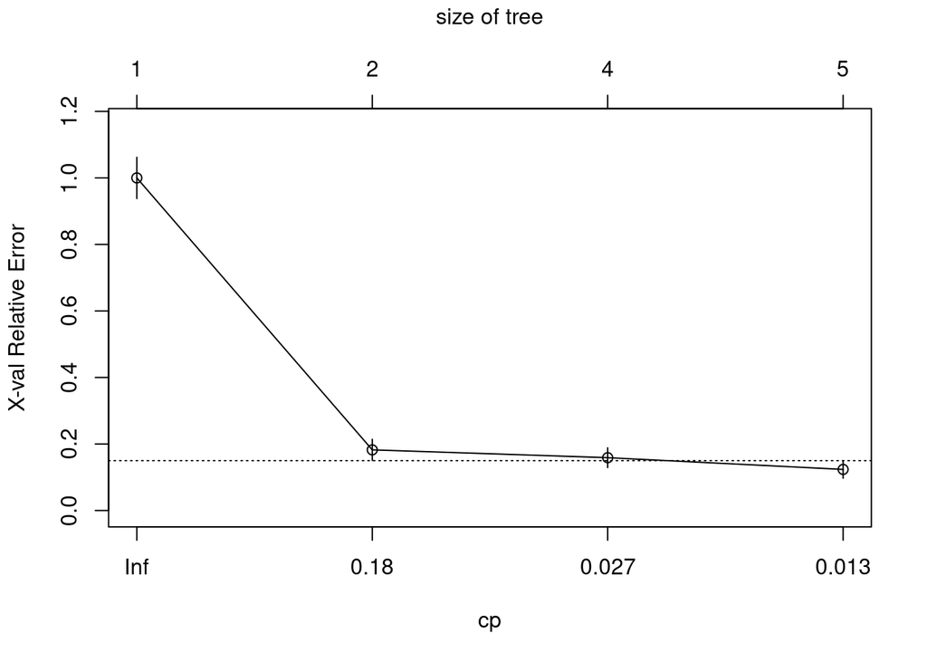

```r
plotcp(dtree)
```

The prune() function uses the complexity parameter to cut back a tree to the desired size. It takes the full tree and snips off the least important splits based on the desired complexity parameter. From the cptable, a tree with four splits has a complexity parameter of 0.01, so the statement prune(dtree, cp=0.01) returns a tree with the desired size

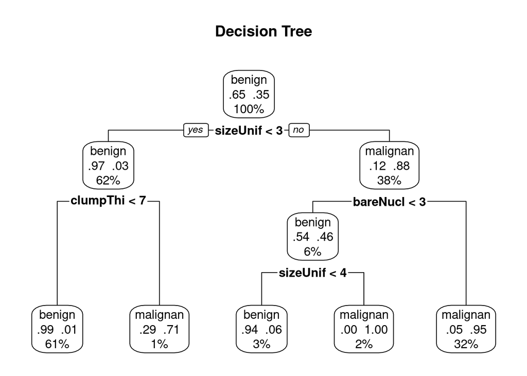

```r
dtree.prunned <- prune(dtree, cp=0.01)
prp(dtree.prunned, type = 2, extra = 104, fallen.leaves = TRUE, main="Decision Tree")
```

The prp() function in the rpart.plot package is used to draw an attractive plot of the final decision tree. The prp() function has many options (see ?prp for details). The type=2 option draws the split labels below each node. The extra=104 parameter includes the probabilities for each class, along with the percentage of observations in each node. The fallen.leaves=TRUE option displays the terminal nodes at the bottom of the graph. To classify an observation, start at the top of the tree, moving to the left branch if a condition is true or to the right otherwise. Continue moving down the tree until you hit a terminal node. Classify the observation using the label of the node.

Traditional (pruned) decision tree for predicting cancer status. Start at the top of the tree, moving left if a condition is true or right otherwise. When an observation hits a terminal node, it’s classified. Each node contains the probability of the classes in that node, along with the percentage of the sample.

```r
# make prediction
dtree.pred <- predict(dtree.prunned, df.validate, type="class")
dtree.perf <- table(df.validate$class, dtree.pred,
                    dnn = c("Actual","Predicted"))
dtree.perf
```

```
##            Predicted
## Actual      benign malignant
##   benign       129        10
##   malignant      2        69
```

Finally, the predict() function is used to classify each observation in the validation sample. A cross-tabulation of the actual status against the predicted status is provided. The overall accuracy was *94%* in the validation sample. Unlike the logistic regression example, all 210 cases in the validation sample could be classified by the final tree. Note that decision trees can be biased toward selecting predictors that have many levels or many missing values.

### ii) Conditional inference trees

Conditional inference trees are similar to traditional trees, but variables and splits are selected based on significance tests rather than purity/homogeneity measures. The significance tests are permutation tests.

In this case, the algorithm is as follows:

1. Calculate pvalues for the relationship between each predictor and the outcome variable.
2. Select the predictor with the lowest p-value.
3. Explore all possible binary splits on the chosen predictor and dependent variable (using permutation tests), and pick the most significant split.
4. Separate the data into these two groups, and continue the process for each subgroup.
5. Continue until splits are no longer significant or the minimum node size is reached.

Conditional inference trees are provided by the ctree() function in the party package. In the next listing, a conditional inference tree is grown for the breast cancer data.

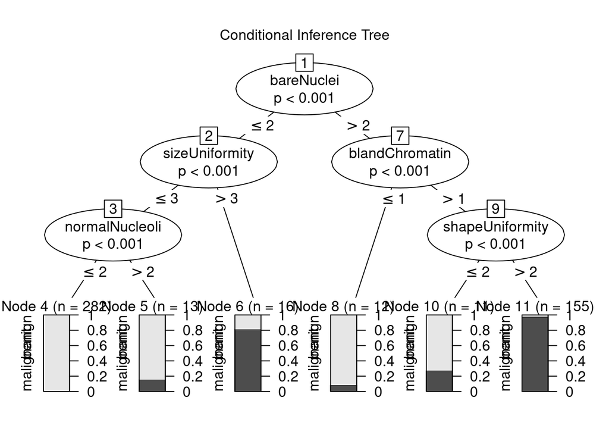

```r
fit.ctree <- ctree(class ~ ., data = df.train)
plot(fit.ctree, main = "Conditional Inference Tree")
```

Note that pruning isn’t required for conditional inference trees, and the process is somewhat more automated. Additionally, the party package has attractive plotting options.  
The shaded area of each node represents the proportion of malignant cases in that node.

#### Displaying an rpart() tree with a ctree()-like graph

If you create a classical decision tree using rpart(), but you’d like to display the resulting tree using a plot like the one in figure above, the partykit package can help. After installing and loading the package, you can use the statement plot(as.party(an.rpart.tree)) to create the desired graph.

We can now access the performance of the conditional inference tree model

```r
ctree.pred <- predict(fit.ctree, df.validate, type="response")
ctree.perf <- table(df.validate$class, ctree.pred,
                    dnn = c("Actual","Predicted"))
ctree.perf
```

```
##            Predicted
## Actual      benign malignant
##   benign       131         8
##   malignant      4        67
```

The decision trees grown by the traditional and conditional methods can differ substantially. In the current example, the accuracy of each is similar (94%).

## c) Random Forest

A random forest is an ensemble learning approach to supervised learning. Multiple predictive models are developed, and the results are aggregated to improve classification rates.

The algorithm for a random forest involves sampling cases and variables to create a large number of decision trees. Each case is classified by each decision tree. The most common classification for that case is then used as the outcome.

Assume that N is the number of cases in the training sample and M is the number of variables. Then the algorithm is as follows:

1. Grow a large number of decision trees by sampling N cases with replacement from the training set.
2. Sample m < M variables at each node. These variables are considered candidates for splitting in that node. The value m is the same for each node.
3. Grow each tree fully without pruning (the minimum node size is set to 1).
4. Terminal nodes are assigned to a class based on the mode of cases in that node.
5. Classify new cases by sending them down all the trees and taking a vote —majority rules.

An out-of-bag (OOB) error estimate is obtained by classifying the cases that aren’t selected when building a tree, using that tree. This is an advantage when a validation sample is unavailable. Random forests also provide a natural measure of variable importance, as you’ll see.

Random forests are grown using the randomForest() function in the randomForest package. The default number of trees is 500, the default number of variables sampled at each node is sqrt(M), and the minimum node size is 1.

The following listing provides the code and results for predicting malignancy status in the breast cancer data.

```r
# grows forest
set.seed(1234)
fit.forest <- randomForest(class ~ ., data = df.train, na.action = na.roughfix,
                           importance = TRUE)
fit.forest
```

```
##
## Call:
##  randomForest(formula = class ~ ., data = df.train, importance = TRUE,      na.action = na.roughfix)
##                Type of random forest: classification
##                      Number of trees: 500
## No. of variables tried at each split: 3
##
##         OOB estimate of  error rate: 2.66%
## Confusion matrix:
##           benign malignant class.error
## benign       313         6  0.01880878
## malignant      7       163  0.04117647
```

the randomForest() function is used to grow 500 traditional decision trees by sampling 489 observations with replacement from the training sample and sampling 3 variables at each node of each tree. The na.action=na.roughfixoption replaces missing values on numeric variables with column medians, and missing values on categorical variables with the modal category for that variable (breaking ties at random).

```r
# Determines variable importance
importance(fit.forest, type = 2)
```

```
##                          MeanDecreaseGini
## clumpThickness                  11.382432
## sizeUniformity                  63.037519
## shapeUniformity                 49.027649
## maginalAdhesion                  4.275345
## singleEpithelialCellSize        14.504981
## bareNuclei                      42.736364
## blandChromatin                  22.484755
## normalNucleoli                  11.375285
## mitosis                          1.755382
```

```r
# prediction
forest.pred <- predict(fit.forest, df.validate)
forest.perf <- table(df.validate$class, forest.pred,
                    dnn = c("Actual","Predicted"))
forest.perf
```

```
##            Predicted
## Actual      benign malignant
##   benign       128         7
##   malignant      2        68
```

Finally, the validation sample is classified using the random forest and the predictive accuracy is calculated . Note that cases with missing values in the validation sample aren’t classified. The prediction accuracy (95.6% overall) is good.

Whereas the randomForest package provides forests based on traditional decision trees, the cforest() function in the party package can be used to generate random forests based on conditional inference trees. If predictor variables are highly correlated, a random forest using conditional inference trees may provide better predictions.

Random forests tend to be very accurate compared with other classification methods. Additionally, they can handle large problems (many observations and variables), can handle large amounts of missing data in the training set, and can handle cases in which the number of variables is much greater than the number of observations. The provision of OOB error rates and measures of variable importance are also significant advantages.

A significant disadvantage is that it’s difficult to understand the classification rules (there are 500 trees!) and communicate them to others. Additionally, you need to store the entire forest in order to classify new cases.

```r
# grows forest using party package
fit.cforest <- cforest(class ~ ., data = df.train, controls = cforest_unbiased())
fit.cforest
```

```
##
##   Random Forest using Conditional Inference Trees
##
## Number of trees:  500
##
## Response:  class
## Inputs:  clumpThickness, sizeUniformity, shapeUniformity, maginalAdhesion, singleEpithelialCellSize, bareNuclei, blandChromatin, normalNucleoli, mitosis
## Number of observations:  489
```

```r
# make prediction
cforest.pred <- predict(fit.cforest, newdata=df.validate)
cforest.perf <- table(df.validate$class, cforest.pred)
cforest.perf
```

```
##            cforest.pred
##             benign malignant
##   benign       131         8
##   malignant      0        71
```

## d) Support Vector Machine

Support vector machines (SVMs) are a group of supervised machine-learningmodels that can be used for classification and regression. They’re popular at present, in part because of their success in developing accurate prediction models, and in part because of the elegant mathematics that underlie the approach. We’ll focus on the use of SVMs for binary classification.

SVMs seek an optimal hyperplane for separating two classes in a multidimensional space. The hyperplane is chosen to maximize the margin between the two classes’ closest points. The points on the boundary of the margin are called support vectors (they help define the margin), and the middle of the margin is the separating hyperplane.

For an N-dimensional space (that is, with N predictor variables), the optimal hyperplane (also called a linear decision surface) has N – 1 dimensions. If there are two variables, the surface is a line. For three variables, the surface is a plane. For 10 variables, the surface is a 9-dimensional hyperplane. Trying to picture it will give you headache.

SVMs are available in R using the ksvm() function in the kernlab package and the svm() function in the e1071 package. The former is more powerful, but the latter is a bit easier to use. The example in the next listing uses the latter (easy is good) to develop an SVM for the Wisconsin breast cancer data.

```r
set.seed(1234)
fit.svm <- svm(class ~ ., data = df.train)
fit.svm
```

```
##
## Call:
## svm(formula = class ~ ., data = df.train)
##
##
## Parameters:
##    SVM-Type:  C-classification
##  SVM-Kernel:  radial
##        cost:  1
##
## Number of Support Vectors:  74
```

```r
svm.pred <- predict(fit.svm, na.omit(df.validate))
svm.perf <- table(na.omit(df.validate)$class, svm.pred,
                  dnn=c("Actual", "Predicted"))
svm.perf
```

```
##            Predicted
## Actual      benign malignant
##   benign       126         9
##   malignant      0        70
```

Because predictor variables with larger variances typically have a greater influence on the development of SVMs, the svm() function scales each variable to a mean of 0 and standard deviation of 1 before fitting the model by default.

Unlike the random forest approach, the SVM is also unable to accommodate missing predictor values when classifying new cases.

### Tuning an SVM

By default, the svm() function uses a radial basis function (RBF) to map samples into a higher-dimensional space (the kernel trick). The RBF kernel is often a good choice because it’s a nonlinear mapping that can handle relations between class labels and predictors that are nonlinear.

When fitting an SVM with the RBF kernel, two parameters can affect the results: gamma and cost. Gamma is a kernel parameter that controls the shape of the separating hyperplane. Larger values of gamma typically result in a larger number of support vectors. Gamma can also be thought of as a parameter that controls how widely a training sample “reaches,” with larger values meaning far and smaller values meaning close. Gamma must be greater than zero.

The cost parameter represents the cost of making errors. A large value severely penalizes errors and leads to a more complex classification boundary. There will be less misclassifications in the training sample, but overfitting may result in poor predictive ability in new samples. Smaller values lead to a flatter classification boundary but may result in under-fitting. Like gamma, cost is always positive.

By default, the svm() function sets gamma to 1 / (number of predictors) and cost to 1. But a different combination of gamma and cost may lead to a more effective model. You can try fitting SVMs by varying parameter values one at a time, but a grid search is more efficient. You can specify a range of values for each parameter using the tune.svm() function. tune.svm() fits every combination of values and reports on the performance of each. An example is given next.

```r
set.seed(1234)
tuned <- tune.svm(class ~ ., data = df.train, gamma = 10^(-6:1), cost = 10^(-10:10))
tuned
```

```
##
## Parameter tuning of 'svm':
##
## - sampling method: 10-fold cross validation
##
## - best parameters:
##  gamma cost
##   0.01    1
##
## - best performance: 0.02740302
```

```r
fit.svm <- svm(class ~ ., data = df.train, gamma = .01, cost = 1)
svm.pred <- predict(fit.svm, na.omit(df.validate))
svm.perf <- table(na.omit(df.validate)$class, svm.pred,
                  dnn = c("Actual","Predicted"))
svm.perf
```

```
##            Predicted
## Actual      benign malignant
##   benign       128         7
##   malignant      0        70
```

Using these parameter values, a new SVM is fit to the training sample. The model is then used to predict outcomes in the validation sample, and the number of errors is displayed. Tuning the modeldecreased the number of errors slightly (from 9 to 7). In many cases, tuning the SVM parameters will lead to greater gains.

As stated previously, SVMs are popular because they work well in many situations. They can also handle situations in which the number of variables is much larger than the number of observations. This has made them popular in the field of biomedicine, where the number of variables collected in a typical DNA microarray study of gene expressions may be one or two orders of magnitude larger than the number of cases available.

One drawback of SVMs is that, like random forests, the resulting classificationrules are difficult to understand and communicate. They’re essentially a black box. Additionally, SVMs don’t scale as well as random forests when building models from large training samples. But once a successful model is built, classifying new observations does scale well.

## Choosing a best predictive solution

The most commonly reported statistic is the accuracy, or how often the classifier is correct. Although informative, the accuracy is insufficient by itself. Additional information is also needed to evaluate the utility of a classification scheme.

Consider a set of rules for classifying individuals as schizophrenic or non- schizophrenic. Schizophrenia is a rare disorder, with a prevalence of roughly 1% in the general population. If you classify everyone as non-schizophrenic, you’ll be right 99% of time. But this isn’t a good classifier because it will also misclassify every schizophrenic as non-schizophrenic. In addition to the accuracy, you should ask these questions:

- What percentage of schizophrenics are correctly identified?
- What percentage of non-schizophrenics are correctly identified?
- If a person is classified as schizophrenic, how likely is it that this classification will be correct?
- If a person is classified as non-schizophrenic, how likely is it that this classification is correct?

These are questions pertaining to a classifier’s sensitivity, specificity, positive predictive power, and negative predictive power.

- *Sensitivity* : Probability of getting a positive classification when the true outcome is positive (also called true positive rate or recall)
- *Specificity :* Probability of getting a negative classification when the true outcome is negative (also called true negative rate)
- *Positive predictive value :* Probability that an observation with a positive classification is correctly identified as positive (also called precision)
- *Negative predictive value :* Probability that an observation with a negative classification is correctly identified as negative
- *Accuracy :* Proportion of observations correctly identified (also called ACC)

A function for calculating these statistics is provided next.

```r
performance <- function(table, n=2){
  if (!all(dim(table) == c(2,2)))
    stop("Must be a 2x2 table")
  tn = table[1,1]
  fp = table[1,2]
  fn = table[2,1]
  tp = table[2,2]
  sensitivity = tp/(tp+fn)
  specificity = tn/(tn+fp)
  ppp = tp/(tp+fp)
  npp = tn/(tn+fn)
  hitrate = (tp+tn)/(tp+tn+fp+fn)
  results <- paste("Sensitivity = ", round(sensitivity, n),
                   "\nSpecificity = ", round(specificity, n),
                   "\nPositive Predictive Value = ", round(ppp, n),
                   "\nNegative Predictive Value = ", round(npp, n),
                   "\nAccuracy = ", round(hitrate, n), "\n", sep = "")
  cat(results)
}
```

The performance() function takes a table containing the true outcome (rows) and predicted outcome (columns) and returns the five accuracy measures. First, the number of true negatives (benign tissue identified as benign), false positives (benign tissue identified as malignant), false negatives (malignant tissue identified as benign), and true positives (malignant tissue identified as malignant) are extracted. Next, these counts are used to calculate the sensitivity, specificity, positive and negative predictive values, and accuracy. Finally, the results are formatted and printed.

```r
print("=============Logistic model===================")
```

```
## [1] "=============Logistic model==================="
```

```r
performance(logit.perf)
```

```
## Sensitivity = 0.99
## Specificity = 0.96
## Positive Predictive Value = 0.93
## Negative Predictive Value = 0.99
## Accuracy = 0.97
```

```r
print("=============Classical decision trees model===================")
```

```
## [1] "=============Classical decision trees model==================="
```

```r
performance(dtree.perf)
```

```
## Sensitivity = 0.97
## Specificity = 0.93
## Positive Predictive Value = 0.87
## Negative Predictive Value = 0.98
## Accuracy = 0.94
```

```r
print("=============Conditional inference trees model===================")
```

```
## [1] "=============Conditional inference trees model==================="
```

```r
performance(ctree.perf)
```

```
## Sensitivity = 0.94
## Specificity = 0.94
## Positive Predictive Value = 0.89
## Negative Predictive Value = 0.97
## Accuracy = 0.94
```

```r
print("=============Random Forest model===================")
```

```
## [1] "=============Random Forest model==================="
```

```r
performance(forest.perf)
```

```
## Sensitivity = 0.97
## Specificity = 0.95
## Positive Predictive Value = 0.91
## Negative Predictive Value = 0.98
## Accuracy = 0.96
```

```r
print("=============Conditional inference Random Forest model===================")
```

```
## [1] "=============Conditional inference Random Forest model==================="
```

```r
performance(cforest.perf)
```

```
## Sensitivity = 1
## Specificity = 0.94
## Positive Predictive Value = 0.9
## Negative Predictive Value = 1
## Accuracy = 0.96
```

```r
print("=============Support Vector Machines model===================")
```

```
## [1] "=============Support Vector Machines model==================="
```

```r
performance(svm.perf)
```

```
## Sensitivity = 1
## Specificity = 0.95
## Positive Predictive Value = 0.91
## Negative Predictive Value = 1
## Accuracy = 0.97
```

Although it’s beyond the scope of this chapter, you can often improve a classification system by trading specificity for sensitivity and vice versa. In the logistic regression model, predict() was used to estimate the probability that a case belonged in the malignant group. If the probability was greater than 0.5, the case was assigned to that group. The 0.5 value is called the threshold or cutoff value. If you vary this threshold, you can increase the sensitivity of the classification model at the expense of its specificity. predict() can generate probabilities for decision trees, random forests, and SVMs as well (although the syntax varies by method).

The impact of varying the threshold value is typically assessed using a receiver operating characteristic (ROC) curve. A ROC curve plots sensitivity versus specificity for a range of threshold values. You can then select a threshold with the best balance of sensitivity and specificity for a given problem. Many R packages generate ROC curves, including ROCR and pROC. Analytic functions in these packages can help you to select the best threshold values for a given scenario or to compare the ROC curves produced by different classificationalgorithms in order to choose the most useful approach. To learn more, see Kuhn & Johnson (2013). A more advanced discussion is offered by Fawcett (2005).